# Data Analysis of Bulk RNA-Sequencing Data from BMP7-Treated Medulloblastoma Cells

Tanaya Datar

02-10-2026

# 1 Introduction

Medulloblastoma (MB) is a pediatric brain cancer with around 5 cases per 1 million individuals (Cooney et al. 2023), occurring due to oncogenic events perturbing the development and differentiation of cerebellar progenitor cells. Bone morphogenetic protein (BMP) plays an important role in cellular differentiation, and has been previously linked to contributing to the development of medulloblastoma. However the exact role that BMP plays clinically and mechanistically in the development of this disease is unknown.

Ohata et al. aimed to explore the mechanisms of the BMP pathways that contribute to the development of medulloblastoma. To investigate this, Ohata et al, performed a bulk RNA-seq experiment designed to identify differences in gene expression in medulloblastoma cell lines (CHLA01, CHLA01R, MB002, and D425) treated with BMP7 ligand for 72 hours and compared them to PBS-treated controls (Ohata et al. 2025).

In this assignment, I analyzed the work of Ohata et. al by examining their bulk RNA-sequencing data to investigate the expression patterns of genes in BMP-treated medulloblastoma cells.

# 2 Dataset Overview

## 2.1 Selecting an appropriate dataset

I am interested in cancer research, specifically brain cancers, which is why medulloblastoma was an area of interest. Additionally, I have worked with scRNA-seq data of medulloblastoma, and bulk-RNA seq data for other organisms like *Drosophila melanogaster*, so this was a opportunity to apply my knowledge of bulk RNA-seq on cancer data.

GSE229150 fit all of my requirements, that I wanted for my dataset:

- It was bulk-RNA seq.
- The paper was published on Mar 28, 2025, and the dataset was available in 2023.
- The paper uses Illumina NovaSeq 6000 which is a state of the art whole transcriptome sequencing platform. Additionally, the dataset had great coverage, with more than 50,000 genes.
- This dataset deals with Homo sapiens species only.
- This dataset has 3 biological replicates per condition.

Additionally, the paper investigates interesting questions such as investigating cancer stem cell capacity, cell death and a positive feedback loop mechanism of BMP, which also contributed to choosing this dataset (Ohata et al. 2025).

To learn more about my data selection approach, view my [Journal Entry](https://github.com/bcb420-2026/Tanaya_Datar/wiki/A1-Dataset-Selection).

## 2.2 Experimental Design

- **GEO Accession:** GSE229150
- **Publication:** [The transcription factor LHX2 mediates and enhances oncogenic BMP signaling in medulloblastoma](https://www.nature.com/articles/s41418-025-01488-6)
- **Experimental Design**
  - A total of 30 samples were used across multiple comparisons:
    - **Cell Lines:** CHLA01, CHLA01R, MB002, and D425 (medulloblastoma cell lines)
    - **Main comparison (24 samples):**
      - **Condition:** BMP7 treatment vs. PBS control for each cell line with three replicates each
      - **Condition:** BMP7 ligand added to growth medium for 72 hours
      - **Control:** PBS-treated cells
      - **Samples:** 3 CHLA01-BMP, 3 CHLA01-Control, 3 CHLA01R-BMP, 3 CHLA01R-Control,  
        3 MB002-BMP, 3 MB002-Control, 3 D425-BMP, 3 D425-Control
    - **Additional comparison (6 samples):**
      - **Condition:** LDN (BMP signaling inhibitor) treatment
      - **Control:** DMSO-treated cells
      - **Samples:** 3 CHLA01R-LDN, 3 CHLA01R-DMSO

# 3 Dataset Curation

## 3.1 Loading Libraries

To begin our analysis, we must first load all relevant libraries that we will use to process and analyze our dataset. The `GEOquery` (Davis and Meltzer 2007) package will be used to retrieve our dataset of interest and additional information from the GEO database. `edgeR` (Chen et al. 2025) package will be used to apply normalization on the dataset. `biomaRt`(Durinck et al. 2009) package will be used to map ENSEMBL IDs to their respective HGNC symbols. `dplyr`(Wickham et al. 2026) and `tidyverse`(Wickham et al. 2019) packages will be used for data manipulation. `ggplot2`(Wickham 2016) package will be used to generate box plots and density plots. `ggrepel`(Slowikowski 2024) package will be used for non-overlapping gene labels in plots, and `pheatmap`(Kolde 2025) package will be used for heatmap visualization.

```r
# Install packages
if (!requireNamespace("BiocManager", quietly = TRUE))
  install.packages("BiocManager")
if (!requireNamespace("tidyverse", quietly = TRUE))
  install.packages("tidyverse")

# Loading required libraries
library(GEOquery)
library(edgeR)
library(biomaRt)
library(dplyr)
library(ggplot2)
library(tidyverse)
library(ggrepel)
library(pheatmap)
```

## 3.2 Dataset Summary

Let us examine the summary of our dataset GSE229150.

```r
# Retrieve data from GEO(Gene Expression Omnibus)
gse <- GEOquery::getGEO("GSE229150", GSEMatrix = TRUE)

# Extracting the object from the list
gse <- gse[[1]]

# Viewing the summary
experimentData(gse)@abstract
```

```
## [1] "In this study, we investigate the potential role of BMP stimulation on the oncogenic capacity of Medulloblastoma cells. BMP7 stimulation demonstrated pleiotropic effects on the investigated cells, inducing high cancer stem cell capacity or cell death. In addition, we uncovered the role of LH…
```

This confirms we are querying the right dataset, and investigating the right question, which is the role of BMP stimulation on the oncogenic capacity of medulloblastoma cells.

## 3.3 Dataset Compilation

The GSE229150 dataset was obtained from the Gene Expression Omnibus (GEO) database using the GEOquery (Davis and Meltzer 2007) Bioconductor package. The raw data consisted of 30 individual feature count output files (one per sample) compressed in the GSE229150_RAW.tar archive, instead of one unified count matrix. Each file contained gene-level read counts for 66,023 annotated genes quantified against the human reference genome GRCh38.

In order to obtain one unified count matrix across all samples, I collated all 30 files by:

1. Reading each feature counts file to extract the count column
2. Verifying gene identifier (ENSEMBL ID) consistency across samples
3. Combining count columns into a single data frame with genes as rows and samples as columns

This collation process transformed 30 separate files into a 66,023 × 30 count matrix, with ENSEMBL gene IDs and gene symbols from the original dataset.

Let us start by understanding the structure of these individual sample files, by looking at its columns and dimensions.

```r
# Querying our dataset of interest.
gse <- GEOquery::getGEO("GSE229150", GSEMatrix = TRUE)

# Accessing each individual file in the .raw
GEOquery::getGEOSuppFiles("GSE229150")

# Untar the RAW file
untar("./GSE229150/GSE229150_RAW.tar", exdir = "./GSE229150")

# Check each sample name matches the test conditions
files <- list.files("./GSE229150", pattern = "\\.txt|\\.gz", full.names = TRUE)

# Reading in one sample file
first_file <- read.table(gzfile("./GSE229150/GSM7155987_UG-3028-CHLA01-BMP1Aligned.sortedByCoord.out_gene.featureCounts.txt.gz"),
                      header = TRUE,
                      sep = "\t")
```

```r
# Investigating the structure of these files:
colnames(first_file)
```

```
## [1] "Geneid"
## [2] "Chr"
## [3] "Start"
## [4] "End"
## [5] "Strand"
## [6] "Length"
## [7] "gene_name"
## [8] "UG.3028.CHLA01.BMP1Aligned.sortedByCoord.out.bam"
```

```r
dim(first_file)
```

```
## [1] 66023     8
```

In order to collate these samples, I then created a base data frame and looped over each of the 30 files, to systematically add each count column. Our collation process results in the final object called count_matrix.

Let us view the structure, column names and dimensions of the final object count_matrix:

```r
# Initialize our base count_matrix and keep the original ENSEMBL IDs and HGNC symbols
count_matrix <- data.frame(
    Geneid = first_file$Geneid,
    gene_name = first_file$gene_name
)

# Looping over each file
for (i in 1:length(files)) {

    # Read each file
    temp <- read.table(
        gzfile(files[i]),
        header = TRUE,
        sep = "\t",
        comment.char = "#"
    )

    # Extract sample name - ONLY the GEO name
    sample_name <- sub("_.*", "", basename(files[i]))

    # Add counts column to the dataframe
    count_matrix[[sample_name]] <- temp[, ncol(temp)]
}
head(count_matrix)
```

|  | Geneid | gene_name | GSM7155987 | GSM7155988 | GSM7155989 | GSM7155990 | GSM7155991 | GSM7155992 | GSM7155993 | GSM7155994 | GSM7155995 | GSM7155996 | GSM7155997 | GSM7155998 | GSM7155999 | GSM7156000 | GSM7156001 | GSM7156002 | GSM7156003 | GSM7156004 | GSM7156005 | GSM7156006 | GSM7156007 | GSM7156008 | GSM7156009 | GSM7156010 | GSM7156011 | GSM7156012 | GSM7156013 | … |
| --- | --- | --- | --- | --- | --- | --- | --- | --- | --- | --- | --- | --- | --- | --- | --- | --- | --- | --- | --- | --- | --- | --- | --- | --- | --- | --- | --- | --- | --- | --- |
| 1 | ENSG00000281764.1 | RP11-399E6.2 | 0 | 0 | 0 | 0 | 0 | 0 | 0 | 0 | 0 | 0 | 0 | 0 | 0 | 0 | 0 | 0 | 0 | 0 | 0 | 0 | 0 | 0 | 0 | 0 | 0 | 0 | 0 | … |
| 2 | ENSG00000281299.1 | AC093151.1 | 0 | 0 | 0 | 0 | 0 | 0 | 0 | 0 | 0 | 0 | 0 | 0 | 0 | 0 | 0 | 0 | 0 | 0 | 0 | 0 | 0 | 0 | 0 | 0 | 0 | 0 | 0 | … |
| 3 | ENSG00000281518.2 | FO681542.1 | 0 | 0 | 0 | 0 | 0 | 0 | 0 | 0 | 0 | 0 | 0 | 0 | 0 | 0 | 0 | 0 | 0 | 0 | 0 | 0 | 0 | 0 | 0 | 0 | 0 | 0 | 0 | … |
| 4 | ENSG00000281876.1 | RP11-399E6.4 | 0 | 0 | 0 | 0 | 0 | 0 | 0 | 0 | 0 | 0 | 0 | 0 | 0 | 0 | 0 | 0 | 0 | 0 | 0 | 0 | 0 | 0 | 0 | 0 | 0 | 0 | 0 | … |
| 5 | ENSG00000281316.1 | DPPA2P2 | 0 | 0 | 0 | 0 | 0 | 0 | 0 | 0 | 0 | 0 | 0 | 0 | 0 | 0 | 0 | 0 | 0 | 0 | 0 | 0 | 0 | 0 | 0 | 0 | 0 | 0 | 0 | … |
| 6 | ENSG00000281877.2 | RPS6KA1 | 0 | 0 | 0 | 0 | 0 | 0 | 0 | 0 | 0 | 0 | 0 | 0 | 0 | 0 | 0 | 0 | 0 | 0 | 0 | 0 | 0 | 0 | 0 | 0 | 0 | 0 | 0 | … |

**Table 1. Collated gene expression count matrix. Each row represents a gene (with ENSEMBL ID and HGNC symbol), and each column corresponds to counts from one of the 30 GEO samples.**

*This code was inspired by the notebook BCB420: “Finding Expression Data with GEOmetadb” rendered notebook (Isserlin 2025b).*

```r
colnames(count_matrix)
```

```
##  [1] "Geneid"     "gene_name"  "GSM7155987" "GSM7155988" "GSM7155989"
##  [6] "GSM7155990" "GSM7155991" "GSM7155992" "GSM7155993" "GSM7155994"
## [11] "GSM7155995" "GSM7155996" "GSM7155997" "GSM7155998" "GSM7155999"
## [16] "GSM7156000" "GSM7156001" "GSM7156002" "GSM7156003" "GSM7156004"
## [21] "GSM7156005" "GSM7156006" "GSM7156007" "GSM7156008" "GSM7156009"
## [26] "GSM7156010" "GSM7156011" "GSM7156012" "GSM7156013" "GSM7156014"
## [31] "GSM7156015" "GSM7156016"
```

```r
dim(count_matrix)
```

```
## [1] 66023    32
```

This dataset contains 66,023 genes, and has 32 columns: 30 samples and 2 columns for ENSEMBL IDs and Gene Symbols.

## 3.4 Generating associated metadata

In order to map each sample with its corresponding treatment condition, I generated a metadata table, from the sample file names.

Below, we see the associated metadata table, its column names and dimensions.

```r
# Extracting the names of the files
file_base <- basename(files)

# Extract GEO ID and getting rid of the extra text
geo_id <- sub("_.*", "", file_base)

# Remove GEO ID and underscore
rest <- sub("^[^_]+_", "", file_base)

# Remove suffix
rest <- sub("Aligned.sortedByCoord.out_gene.featureCounts.txt.gz$", "", rest)

# Split by "-"
split_info <- strsplit(rest, "-")

# Extract cell line
cell_line <- sapply(split_info, function(x) {
  # Cell line is the last element before the condition
  # Last element is the condition (BMP1/Cont1/DMSO1)
  x[length(x)-1]
})

# Extract treatment condition
condition <- sapply(split_info, function(x) {
  # Condition is always the last element
  x[length(x)]
})

# Building  metadata table
metadata <- data.frame(
  GEO_ID = geo_id,
  cell_line = cell_line,
  condition = condition,
  file = files,
  stringsAsFactors = FALSE
)

# Strip trailing numbers from condition; We want to group BMP1,BMP2, and BMP3 together.
metadata$condition <- sub("[0-9]+$", "", metadata$condition)

# View the metadata
metadata
```

| GEO_ID | cell_line | condition | file |
| --- | --- | --- | --- |
| GSM7155987 | CHLA01 | BMP | ./GSE229150/GSM7155987_UG-3028-CHLA01-BMP1Aligned.sortedByCoord.out_gene.featureCounts.txt.gz |
| GSM7155988 | CHLA01 | BMP | ./GSE229150/GSM7155988_UG-3028-CHLA01-BMP2Aligned.sortedByCoord.out_gene.featureCounts.txt.gz |
| GSM7155989 | CHLA01 | BMP | ./GSE229150/GSM7155989_UG-3028-CHLA01-BMP3Aligned.sortedByCoord.out_gene.featureCounts.txt.gz |
| GSM7155990 | CHLA01 | Cont | ./GSE229150/GSM7155990_UG-3028-CHLA01-Cont1Aligned.sortedByCoord.out_gene.featureCounts.txt.gz |
| GSM7155991 | CHLA01 | Cont | ./GSE229150/GSM7155991_UG-3028-CHLA01-Cont2Aligned.sortedByCoord.out_gene.featureCounts.txt.gz |
| GSM7155992 | CHLA01 | Cont | ./GSE229150/GSM7155992_UG-3028-CHLA01-Cont3Aligned.sortedByCoord.out_gene.featureCounts.txt.gz |
| GSM7155993 | CHLA01R | BMP | ./GSE229150/GSM7155993_UG-3028-CHLA01R-BMP1Aligned.sortedByCoord.out_gene.featureCounts.txt.gz |
| GSM7155994 | CHLA01R | BMP | ./GSE229150/GSM7155994_UG-3028-CHLA01R-BMP2Aligned.sortedByCoord.out_gene.featureCounts.txt.gz |
| GSM7155995 | CHLA01R | BMP | ./GSE229150/GSM7155995_UG-3028-CHLA01R-BMP3Aligned.sortedByCoord.out_gene.featureCounts.txt.gz |
| GSM7155996 | CHLA01R | Cont | ./GSE229150/GSM7155996_UG-3028-CHLA01R-Cont1Aligned.sortedByCoord.out_gene.featureCounts.txt.gz |

[output cut: 20 more lines]

**Table 2. Sample metadata table linking each GEO sample to its corresponding cell line and treatment condition, extracted from file names and standardized for downstream analysis.**

```r
dim(metadata)
```

```
## [1] 30  4
```

```r
colnames(metadata)
```

```
## [1] "GEO_ID"    "cell_line" "condition" "file"
```

To learn more about my data collation approach, view my [Journal Entry](https://github.com/bcb420-2026/Tanaya_Datar/wiki/A1-Dataset-Curation).

# 4 Dataset Cleaning

## 4.1 Removing Low Read Counts

Let us analyze some statistics (metrics of mean, median, min, max, 1st quartile, 3rd quartile) to assess data quality:

```r
# Analyzing metrics of mean, median, min, max, 1st quartile, 3rd quartile using the summary function.

# Do not include the HGNC symbols and ENSEMBL IDs
only_counts <- count_matrix[, -c(1,2)]
count_stats <- sapply(only_counts, summary)

# Converting it to a dataframe for easier viewing:
count_stats_df <- as.data.frame(count_stats)

# View results
count_stats_df
```

|  | GSM7155987 | GSM7155988 | GSM7155989 | GSM7155990 | GSM7155991 | GSM7155992 | GSM7155993 | GSM7155994 | GSM7155995 | GSM7155996 | GSM7155997 | GSM7155998 | GSM7155999 | GSM7156000 | GSM7156001 | GSM7156002 | GSM7156003 | GSM7156004 | GSM7156005 | GSM7156006 | GSM7156007 | GSM7156008 | GSM7156009 | GSM7156010 | GSM7156011 | GSM7156012 | GSM7156013 | GSM7156014 | GSM7156015 | … |
| --- | --- | --- | --- | --- | --- | --- | --- | --- | --- | --- | --- | --- | --- | --- | --- | --- | --- | --- | --- | --- | --- | --- | --- | --- | --- | --- | --- | --- | --- | --- |
| Min. | 0.0000 | 0.0000 | 0.0000 | 0.0000 | 0.0000 | 0.0000 | 0.0000 | 0.0000 | 0.0000 | 0.0000 | 0.0000 | 0.0000 | 0.0000 | 0.0000 | 0.0000 | 0.0000 | 0.0000 | 0.000 | 0.0000 | 0.0000 | 0.0000 | 0.0000 | 0.0000 | 0.0000 | 0.0000 | 0.000 | 0.0000 | 0.0000 | 0.0000 | … |
| 1st Qu. | 0.0000 | 0.0000 | 0.0000 | 0.0000 | 0.0000 | 0.0000 | 0.0000 | 0.0000 | 0.0000 | 0.0000 | 0.0000 | 0.0000 | 0.0000 | 0.0000 | 0.0000 | 0.0000 | 0.0000 | 0.000 | 0.0000 | 0.0000 | 0.0000 | 0.0000 | 0.0000 | 0.0000 | 0.0000 | 0.000 | 0.0000 | 0.0000 | 0.0000 | … |
| Median | 0.0000 | 0.0000 | 0.0000 | 0.0000 | 0.0000 | 0.0000 | 0.0000 | 0.0000 | 0.0000 | 0.0000 | 0.0000 | 0.0000 | 0.0000 | 0.0000 | 0.0000 | 0.0000 | 0.0000 | 0.000 | 2.0000 | 0.0000 | 0.0000 | 0.0000 | 0.0000 | 0.0000 | 0.0000 | 0.000 | 0.0000 | 0.0000 | 0.0000 | … |
| Mean | 347.2828 | 245.4023 | 326.6881 | 275.8503 | 329.2424 | 273.0779 | 330.2149 | 337.0657 | 387.6776 | 356.7913 | 338.3989 | 372.0751 | 380.4411 | 368.4181 | 330.5315 | 333.4013 | 404.8822 | 354.487 | 358.4198 | 370.7466 | 361.0865 | 372.1099 | 391.2125 | 331.8012 | 368.8125 | 332.416 | 389.5113 | 410.7448 | 461.1023 | … |
| 3rd Qu. | 9.0000 | 7.0000 | 10.0000 | 7.0000 | 9.0000 | 8.0000 | 11.0000 | 12.0000 | 14.0000 | 12.0000 | 9.0000 | 11.0000 | 6.0000 | 6.0000 | 5.0000 | 5.0000 | 6.0000 | 6.000 | 19.0000 | 11.0000 | 12.0000 | 10.0000 | 10.0000 | 8.0000 | 6.0000 | 5.000 | 5.0000 | 5.0000 | 6.0000 | … |
| Max. | 2242163.0000 | 2566262.0000 | 2386146.0000 | 1421910.0000 | 1980365.0000 | 2270349.0000 | 1252307.0000 | 1070410.0000 | 1350506.0000 | 1014293.0000 | 719822.0000 | 860854.0000 | 2199083.0000 | 2135670.0000 | 2058180.0000 | 2211261.0000 | 2123054.0000 | 2615674.000 | 1160566.0000 | 1199662.0000 | 1302743.0000 | 781460.0000 | 800579.0000 | 865114.0000 | 1338894.0000 | 1266950.000 | 1817865.0000 | 1478590.0000 | 1896646.0000 | … |

**Table 3. Summary statistics of gene expression counts across all samples, showing minimum, 1st quartile, median, mean, 3rd quartile, and maximum values to assess data quality.**

**INFERENCE:**

If we analyze our treatment conditions, we see the following grouping:

```r
table(metadata$condition)
```

```
##
##  BMP Cont DMSO  LDN
##   12   12    3    3
```

**INFERENCE:**

The dataset contains 12 samples each in the BMP and Control conditions, and 3 samples each in the DMSO and LDN conditions. Using edgeR (Chen et al. 2025), we will only keep genes expressed above 1 CPM (Counts per million) in at least 3 samples, as 3 is the smallest condition group (DMSO or LDN). Keeping the threshold as 1 CPM removes lowly expressed genes that may reflect background noise rather than true signal. Additionally, keeping the sample limit as 3 ensures that genes with potentially meaningful expression are not inadvertently removed.

```r
# For easier analysis, let us assign the rownames as ENSEMBL IDs.
rownames(only_counts) <- count_matrix$Geneid

# Calculate CPM to account for library sizes
cpm_counts <-  edgeR::cpm(only_counts)
# Defining our smallest group
min_samples <- 3
# Keep genes expressed only above 1 CPM in at least 3 samples
keep <- rowSums(cpm_counts > 1) >= min_samples
# Subset the original count matrix to keep only those genes
filtered_counts <- only_counts[keep, ]
```

*This code was inspired by (Bioconductor Support Forum 2023) and BCB420: Computational Systems Biology Lectures (Isserlin 2025a).*

Now, let us re-analyze our dataset statistics post filtering:

```r
# Testing summary statistics again
count_stats_post_filtering <- sapply(filtered_counts, summary)

# Converting it to a dataframe for easier viewing:
count_stats_post_filtering_df <- as.data.frame(count_stats_post_filtering)

# View the results post filtering
count_stats_post_filtering_df
```

|  | GSM7155987 | GSM7155988 | GSM7155989 | GSM7155990 | GSM7155991 | GSM7155992 | GSM7155993 | GSM7155994 | GSM7155995 | GSM7155996 | GSM7155997 | GSM7155998 | GSM7155999 | GSM7156000 | GSM7156001 | GSM7156002 | GSM7156003 | GSM7156004 | GSM7156005 | GSM7156006 | GSM7156007 | GSM7156008 | GSM7156009 | GSM7156010 | GSM7156011 | GSM7156012 | GSM7156013 | GSM7156014 | GSM7156015 | … |
| --- | --- | --- | --- | --- | --- | --- | --- | --- | --- | --- | --- | --- | --- | --- | --- | --- | --- | --- | --- | --- | --- | --- | --- | --- | --- | --- | --- | --- | --- | --- |
| Min. | 0.000 | 0.0000 | 0.000 | 0.000 | 0.000 | 0.000 | 0.000 | 0.000 | 0.000 | 0.0 | 0.000 | 0.000 | 0.000 | 0.000 | 0.000 | 0.000 | 0.000 | 0.000 | 0.00 | 0.000 | 0.000 | 0.000 | 0.000 | 0.000 | 0.000 | 0.000 | 0.000 | 0.000 | 0.000 | … |
| 1st Qu. | 34.000 | 26.0000 | 34.000 | 28.000 | 34.000 | 28.000 | 45.000 | 46.000 | 55.000 | 45.0 | 36.000 | 43.000 | 26.000 | 25.000 | 21.000 | 20.000 | 28.000 | 23.000 | 49.00 | 41.000 | 42.000 | 36.000 | 38.000 | 32.000 | 22.000 | 18.000 | 21.000 | 23.000 | 24.000 | … |
| Median | 265.000 | 178.0000 | 261.000 | 235.000 | 277.000 | 217.000 | 327.000 | 335.000 | 389.000 | 363.0 | 327.000 | 368.000 | 261.000 | 243.000 | 213.000 | 191.000 | 286.000 | 220.000 | 376.00 | 379.000 | 376.000 | 351.000 | 367.000 | 311.000 | 245.000 | 197.000 | 234.000 | 266.000 | 282.000 | … |
| Mean | 1306.925 | 923.2286 | 1229.193 | 1038.095 | 1238.952 | 1027.507 | 1241.952 | 1267.718 | 1457.965 | 1342.1 | 1273.424 | 1399.913 | 1432.578 | 1387.272 | 1244.686 | 1255.495 | 1524.573 | 1334.814 | 1343.13 | 1394.353 | 1357.856 | 1400.214 | 1472.124 | 1248.583 | 1388.647 | 1251.675 | 1466.712 | 1546.583 | 1736.259 | … |
| 3rd Qu. | 969.000 | 614.0000 | 921.000 | 834.000 | 970.000 | 753.000 | 1080.000 | 1127.000 | 1287.000 | 1238.0 | 1157.000 | 1284.000 | 1052.000 | 1002.000 | 875.000 | 824.000 | 1150.000 | 899.000 | 1272.00 | 1318.000 | 1286.000 | 1327.000 | 1394.000 | 1174.000 | 1014.000 | 855.000 | 986.000 | 1129.000 | 1230.000 | … |
| Max. | 2242163.000 | 2566262.0000 | 2386146.000 | 1421910.000 | 1980365.000 | 2270349.000 | 1252307.000 | 1070410.000 | 1350506.000 | 1014293.0 | 719822.000 | 860854.000 | 2199083.000 | 2135670.000 | 2058180.000 | 2211261.000 | 2123054.000 | 2615674.000 | 1160566.00 | 1199662.000 | 1302743.000 | 781460.000 | 800579.000 | 865114.000 | 1338894.000 | 1266950.000 | 1817865.000 | 1478590.000 | 1896646.000 | … |

**Table 4. Summary statistics of the filtered gene expression matrix, showing minimum, 1st quartile, median, mean, 3rd quartile, and maximum values after removing lowly expressed genes to evaluate the effect of filtering on data distribution.**

**INFERENCE:**

The post-filtering summary statistics show that median read counts have substantially increased across samples, with 50% of genes now having median values ~200. This indicates that low-count genes, which previously contributed read counts of zero, have been effectively removed resulting in a dataset enriched for genes with possibly meaningful expression.

Let us reassess our coverage:

```r
dim(filtered_counts)
```

```
## [1] 17517    30
```

This has reduced our genes from 66,023 genes to 17,517 genes.

## 4.2 Identifier Mapping

Our original dataset is already mapped with HGNC symbols, however as mappings can be one-to-many and with new ENSEMBL/HGNC and genome build releases, these mappings can change (Isserlin 2025b).

Let us analyze our dataset first for duplicates:

```r
# Extract the HGNC gene names of the filtered counts from the paper's original dataset
filtered_gene_names <- count_matrix$gene_name[match(rownames(filtered_counts), count_matrix$Geneid)]

# Test if any duplicates exist
any(duplicated(filtered_gene_names))
```

```
## [1] TRUE
```

```r
length(which(duplicated(filtered_gene_names)))
```

```
## [1] 37
```

**INFERENCE:**

The original mapping has 37 duplicates of HGNC symbols.

Let us try to perform identifier mapping on our dataset using the current biomaRt database, and see if duplicate numbers improve.

```r
# Loading the correct database with increased timeout
ensembl <- useEnsembl(
    biomart = "genes",
    dataset = "hsapiens_gene_ensembl",
    mirror = "useast"
)

# We want to query for human genes only
ensembl <- biomaRt::useDataset("hsapiens_gene_ensembl", mart = ensembl)

# Increasing timeout to prevent connection errors which I got during knitting
options(timeout = 300)

# Stripping off the version number
strip_ensembl_version <- function(x) sub("\\..*$", "", x)

# Get ENSEMBL IDs from the rownames
ids <- rownames(filtered_counts)
ids_clean <- strip_ensembl_version(ids)

# Map each ENSEMBL ID to its corresponding HGNC symbol
map <- biomaRt::getBM(
  attributes = c("ensembl_gene_id", "hgnc_symbol"),
  filters = "ensembl_gene_id",
  values = ids_clean,
  mart = ensembl
)

# A view of the mapping
head(map)
```

|  | ensembl_gene_id | hgnc_symbol |
| --- | --- | --- |
| 1 | ENSG00000000457 | SCYL3 |
| 2 | ENSG00000000460 | FIRRM |
| 3 | ENSG00000000971 | CFH |
| 4 | ENSG00000001460 | STPG1 |
| 5 | ENSG00000001461 | NIPAL3 |
| 6 | ENSG00000002016 | RAD52 |

**Table 5. Mapping of ENSEMBL gene IDs to HGNC symbols using the current Ensembl biomaRt database, showing a subset of results which help to assess the resolution of duplicate gene symbols in the dataset.**

*This code was inspired by BCB420: “Identifier Mapping” rendered notebook (Isserlin 2025b).*

Let us now compare our mapping to the original mapping done by the paper.

The number of ENSEMBL IDs we wanted to map:

```r
# Check mapping coverage

# Number of ENSEMBL IDs they tried to match
length(ids_clean)
```

```
## [1] 17517
```

The number of ENSEMBL IDs we were able to map:

```r
# Number of IDs successfully mapped
nrow(map)
```

```
## [1] 17160
```

The number of ENSEMBL IDs we failed to to map:

```r
length(ids_clean) - nrow(map)
```

```
## [1] 357
```

**INFERENCE:**

As the number is large, I will use the original mapping done by the paper.

## 4.3 Handling Duplicates

Let us investigate those 37 duplicates in the original mapping. These are the names of the duplicated HGNC symbols.

```r
#Names of genes that are duplicated HGNC symbols
unique_duplicated_genes <- unique(filtered_gene_names[which(duplicated(filtered_gene_names))])

# List of duplicated gene symbols
unique_duplicated_genes
```

```
##  [1] "CROCCP2"     "U1"          "RGS5"        "ZNF670"      "WASH7P"
##  [6] "Metazoa_SRP" "Y_RNA"       "SNORA79"     "PKD1P6"      "PAGR1"
## [11] "C2orf15"     "CBS"         "DGCR6"       "uc_338"      "SNORD19"
## [16] "SNORD63"     "SNORA74"     "MATR3"       "SOGA3"       "SNORA22"
## [21] "U3"          "RPL41"       "PGM5-AS1"    "SNORA11"     "IDS"
```

```r
# Number of duplicates
length(unique_duplicated_genes)
```

```
## [1] 25
```

There are 25 unique duplicated HGNC symbols. Let us investigate the roles of these proteins, by querying biomaRt (Durinck et al. 2009).

```r
# Connecting to Ensembl
ensembl <- useEnsembl(biomart = "genes", dataset = "hsapiens_gene_ensembl")
```

```
## Ensembl site unresponsive, trying useast mirror
```

```r
# Genes to examine
genes_to_check <- c(
  "CROCCP2", "U1", "RGS5", "ZNF670",
  "WASH7P", "Metazoa_SRP", "Y_RNA", "SNORA79",
  "PKD1P6", "PAGR1", "C2orf15", "CBS",
  "DGCR6", "uc_338", "SNORD19", "SNORD63",
  "SNORA74", "MATR3", "SOGA3", "SNORA22",
  "U3", "RPL41", "PGM5-AS1", "SNORA11",
  "IDS"
)

# Query gene biotypes
gene_info <- biomaRt::getBM(
  attributes = c("external_gene_name", "gene_biotype"),
  filters = "external_gene_name",
  values = genes_to_check,
  mart = ensembl
)

# View their information
gene_info
```

| external_gene_name | gene_biotype |
| --- | --- |
| Y_RNA | misc_RNA |
| U1 | snRNA |
| Metazoa_SRP | misc_RNA |
| U3 | snoRNA |
| PKD1P6 | transcribed_unprocessed_pseudogene |
| CBS | protein_coding |
| SNORA11 | snoRNA |
| PGM5-AS1 | lncRNA |
| SNORA22 | snoRNA |
| SNORD63 | snoRNA |

[output cut: 14 more lines]

**Table 6. Biotype classification of 25 genes with duplicated HGNC symbols, retrieved from Ensembl via biomaRt, highlighting their roles as protein-coding genes, pseudogenes, long non-coding RNAs, or small nucleolar RNAs.**

*This code was inspired by BCB420: “Finding Expression Data with GEOmetadb” rendered notebook (Isserlin 2025b).*

**INFERENCE:**

U1, U3, Y_RNA, SNORA79, SNORD19, SNORD63, SNORA74, SNORA22, SNORA11, WASH7P, PKD1P6, uc_338, SOGA3, C2orf15, PGM5-AS1, CROCCP2, Metazoa_SRP, and RPL41 genes are either small RNAs, pseudogenes, non-coding RNAs or ribosomal proteins. As these genes are unlikely to play a role in the development of medulloblastoma, and will unlikely impact our analysis, let us filter them out from our dataset.

```r
# Adding gene column to filtered_counts
filtered_counts$HGNC_symbol <- filtered_gene_names

# Defining genes to remove completely
genes_to_remove <- c(
  "CROCCP2", "U1", "WASH7P", "Metazoa_SRP", "Y_RNA", "SNORA79",
  "PKD1P6", "C2orf15", "uc_338", "SNORD19", "SNORD63",
  "SNORA74", "SOGA3", "SNORA22",
  "U3", "RPL41", "PGM5-AS1", "SNORA11")


# Removing those genes
counts_pseudo_removed <- filtered_counts[!filtered_counts$HGNC_symbol %in% genes_to_remove, ]

# Coverage of Dataset
dim(counts_pseudo_removed)
```

```
## [1] 17469    31
```

There are now 17,469 genes.

RGS5, ZNF670, PAGR1, CBS, DGCR6, MATR3, IDS genes are considered to have important roles in development. As these proteins can be possibly involved in cancer development and regulation, I decided not to filter them out. Let us analyze the expression of a certain duplicated gene MATR3.

```r
# Subset for a specific protein of interest
subset_df <- counts_pseudo_removed[counts_pseudo_removed$HGNC_symbol == "MATR3", ]

# View the subsetted data frame
subset_df
```

|  | GSM7155987 | GSM7155988 | GSM7155989 | GSM7155990 | GSM7155991 | GSM7155992 | GSM7155993 | GSM7155994 | GSM7155995 | GSM7155996 | GSM7155997 | GSM7155998 | GSM7155999 | GSM7156000 | GSM7156001 | GSM7156002 | GSM7156003 | GSM7156004 | GSM7156005 | GSM7156006 | GSM7156007 | GSM7156008 | GSM7156009 | GSM7156010 | GSM7156011 | GSM7156012 | GSM7156013 | GSM7156014 | GSM7156015 | … |
| --- | --- | --- | --- | --- | --- | --- | --- | --- | --- | --- | --- | --- | --- | --- | --- | --- | --- | --- | --- | --- | --- | --- | --- | --- | --- | --- | --- | --- | --- | --- |
| ENSG00000280987.2 | 587 | 324 | 481 | 455 | 579 | 426 | 125 | 155 | 131 | 456 | 418 | 406 | 389 | 393 | 285 | 337 | 418 | 366 | 339 | 345 | 298 | 303 | 267 | 214 | 477 | 422 | 540 | 450 | 452 | … |
| ENSG00000015479.17 | 574 | 552 | 667 | 423 | 468 | 505 | 469 | 514 | 522 | 624 | 472 | 577 | 378 | 385 | 286 | 335 | 379 | 392 | 322 | 353 | 411 | 337 | 330 | 301 | 488 | 376 | 487 | 452 | 597 | … |

**Table 7. Expression values of the gene MATR3 across all samples, retained due to its potential developmental and cancer-related roles**

**INFERENCE:**

We obtain our final count data with no duplicates:

```r
# Wrote a function to generate our final count data

mutate_mean_expr <- function(df, gene_col, expr_cols = NULL) {
  # When null, it selects all non-gene-symbol columns as numeric expression columns
  if (is.null(expr_cols)) {
    expr_cols <- setdiff(colnames(df), gene_col)
  }

  # Ensure expression columns are numeric
  df[expr_cols] <- lapply(df[expr_cols], as.numeric)

  # Collapse duplicates using library dplyr
  collapsed_df <- df %>%
    # Group by gene symbol
     group_by(across(all_of(gene_col))) %>%
    # Average numeric columns
    summarise(across(all_of(expr_cols), mean), .groups = "drop") %>%
    as.data.frame()

  # Set rownames as gene symbols and remove the column
  rownames(collapsed_df) <- collapsed_df[[gene_col]]
  collapsed_df[[gene_col]] <- NULL

  return(collapsed_df)
}

# Calling that function for our dataset
final_mapped_counts <- mutate_mean_expr(
  df = counts_pseudo_removed,
  gene_col = "HGNC_symbol"
)

# View the final data
head(final_mapped_counts)
```

|  | GSM7155987 | GSM7155988 | GSM7155989 | GSM7155990 | GSM7155991 | GSM7155992 | GSM7155993 | GSM7155994 | GSM7155995 | GSM7155996 | GSM7155997 | GSM7155998 | GSM7155999 | GSM7156000 | GSM7156001 | GSM7156002 | GSM7156003 | GSM7156004 | GSM7156005 | GSM7156006 | GSM7156007 | GSM7156008 | GSM7156009 | GSM7156010 | GSM7156011 | GSM7156012 | GSM7156013 | GSM7156014 | GSM7156015 | … |
| --- | --- | --- | --- | --- | --- | --- | --- | --- | --- | --- | --- | --- | --- | --- | --- | --- | --- | --- | --- | --- | --- | --- | --- | --- | --- | --- | --- | --- | --- | --- |
| A1BG | 2 | 6 | 10 | 4 | 9 | 9 | 25 | 41 | 42 | 37 | 27 | 22 | 11 | 5 | 6 | 8 | 10 | 10 | 16 | 7 | 12 | 7 | 8 | 13 | 6 | 4 | 7 | 7 | 6 | … |
| A1BG-AS1 | 105 | 60 | 75 | 88 | 103 | 66 | 245 | 211 | 283 | 213 | 183 | 191 | 89 | 58 | 78 | 79 | 113 | 72 | 180 | 150 | 112 | 144 | 124 | 152 | 112 | 74 | 107 | 122 | 89 | … |
| A2M | 5 | 3 | 7 | 13 | 12 | 13 | 5 | 3 | 1 | 2 | 1 | 0 | 0 | 2 | 0 | 1 | 0 | 1 | 168 | 159 | 193 | 139 | 154 | 140 | 8 | 7 | 7 | 3 | 3 | … |
| A2M-AS1 | 34 | 36 | 50 | 41 | 40 | 44 | 34 | 40 | 47 | 71 | 44 | 75 | 17 | 6 | 20 | 13 | 10 | 14 | 18 | 6 | 11 | 6 | 10 | 6 | 6 | 1 | 3 | 9 | 10 | … |
| A2ML1 | 2 | 2 | 5 | 1 | 0 | 1 | 2 | 0 | 1 | 0 | 0 | 0 | 0 | 0 | 2 | 0 | 1 | 0 | 112 | 79 | 88 | 16 | 28 | 19 | 0 | 0 | 0 | 0 | 0 | … |
| AAAS | 1257 | 820 | 1183 | 1271 | 1618 | 1024 | 1114 | 1018 | 1314 | 1609 | 1465 | 1658 | 1599 | 1369 | 1174 | 1142 | 1891 | 1317 | 2185 | 2201 | 2265 | 1832 | 1809 | 1644 | 1255 | 1136 | 1339 | 1805 | 1773 | … |

**Table 8. Final gene expression count matrix with duplicates removed by averaging expression values across repeated HGNC symbols.**

To learn more about my function writing approach, view my [Journal Entry](https://github.com/bcb420-2026/Tanaya_Datar/wiki/A1-Progress-Updates).

Let us check if our function worked correctly by analyzing the values.

```r
# Subset for a specific protein of interest
subset_MATR3 <- final_mapped_counts[rownames(final_mapped_counts)== "MATR3",]

# View the subsetted data frame
subset_MATR3
```

|  | GSM7155987 | GSM7155988 | GSM7155989 | GSM7155990 | GSM7155991 | GSM7155992 | GSM7155993 | GSM7155994 | GSM7155995 | GSM7155996 | GSM7155997 | GSM7155998 | GSM7155999 | GSM7156000 | GSM7156001 | GSM7156002 | GSM7156003 | GSM7156004 | GSM7156005 | GSM7156006 | GSM7156007 | GSM7156008 | GSM7156009 | GSM7156010 | GSM7156011 | GSM7156012 | GSM7156013 | GSM7156014 | GSM7156015 | … |
| --- | --- | --- | --- | --- | --- | --- | --- | --- | --- | --- | --- | --- | --- | --- | --- | --- | --- | --- | --- | --- | --- | --- | --- | --- | --- | --- | --- | --- | --- | --- |
| MATR3 | 580.5 | 438 | 574 | 439 | 523.5 | 465.5 | 297 | 334.5 | 326.5 | 540 | 445 | 491.5 | 383.5 | 389 | 285.5 | 336 | 398.5 | 379 | 330.5 | 349 | 354.5 | 320 | 298.5 | 257.5 | 482.5 | 399 | 513.5 | 451 | 524.5 | … |

**Table 9. Expression values of MATR3 after collapsing duplicates, confirming that the final count matrix correctly averages repeated entries for each gene.**

**INFERENCE:**

From Table 7, we see that GSM7155987 had read counts of 587 and 574 for gene MATR3.Now, we see only one row for MATR3, with a read count of 580.5, which is a average of the values 587 and 574.

Let us investigate if our identifier mapping is complete.

How many genes did we have originally before mapping?

```r
# Check if this worked

# How many genes did we have originally?
nrow(filtered_counts)
```

```
## [1] 17517
```

How many genes do we have now after removing duplicates?

```r
# How many genes do we have now?
nrow(final_mapped_counts)
```

```
## [1] 17462
```

Are there any duplicated genes in our mapped dataset?

```r
# Are there any duplicated genes left?
any(duplicated(rownames(final_mapped_counts)))
```

```
## [1] FALSE
```

**INFERENCE:**

These results verify that we do not have any duplicates with a great coverage of 17462 genes, and have successfully completed Identifier Mapping.

## 4.4 Outlier Detection

Although low-expression genes were filtered, outliers may still be present due to technical variation or genuinely high gene expression (Isserlin 2025a). The [paper](https://www.nature.com/articles/s41418-025-01488-6) associated with our dataset, claims that there are no outliers present. Let us confirm this.

To identify potential outliers in the dataset, let us apply the following workflow:

1. Using library edgeR to normalize this dataset (TMM method)
2. Plot a PCA plot
3. Plot a MDS plot
4. Detect outliers

Let us first normalize this dataset using edgeR (Chen et al. 2025) by performing log normalization.

```r
# Create DGEList object
dge <- edgeR::DGEList(counts = final_mapped_counts)

# Calculate normalization factors (TMM method)
dge <- edgeR::calcNormFactors(dge, method = "TMM")

# Calculate log-CPM values
logcpm <- edgeR::cpm(dge, log = TRUE, prior.count = 1)
```

*This code was inspired by BCB420: Computational Systems Biology Lectures (Isserlin 2025a).*

## 4.5 Generating PCA plot

Now let us use this normalized data to generate a PCA plot. A PCA plot will allow us to see our samples labeled by conditions and possibly detect outliers.

In our dataset, along with 4 different conditions(BMP, Cont, DMSO, LDN), we also have 4 different cell lines(CHLA01R, D425, CHLA01, MB002). We consider those factors in our clustering code below. Let us observe our PCA plot.

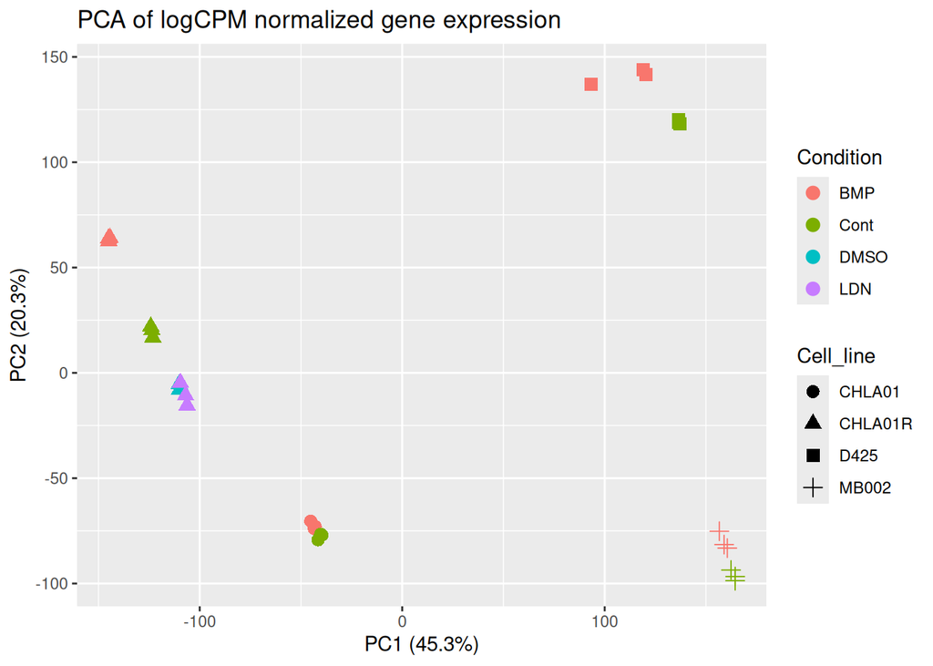

```r
# Transpose because prcomp expects samples as rows
logcpm_t <- t(logcpm)

# Run PCA
pca_result <- prcomp(logcpm_t, scale. = FALSE)

# Extract PC scores for PC1 and PC2
pca_df <- data.frame(pca_result$x[,c(1,2)])

# Match each sample to condition
pca_df$Condition <- metadata$condition
pca_df$Cell_line <- metadata$cell_line

# Calculate variance explained by each PC
variance_explained <- summary(pca_result)$importance[2, ] * 100

# Plot PC1 vs PC2
ggplot(pca_df, aes(PC1, PC2, color = Condition, shape = Cell_line)) +
  geom_point(size =3) +
  labs(title = "PCA of logCPM normalized gene expression",
       x = paste0("PC1 (", round(variance_explained[1],1), "%)"),
    y = paste0("PC2 (", round(variance_explained[2],1), "%)"),)
```

**Figure 1. PCA plot of TMM-normalized log-CPM gene expression across 30 samples. Samples are colored by condition (BMP, Control, DMSO, LDN) and shaped by cell line (CHLA01R, D425, CHLA01, MB002). This plot allows visualization of sample clustering and identification of potential outliers.**

*This code was inspired by (Harvey and Hanson 2024).*

**INFERENCE**:

The PCA plot shows that samples generally cluster together, with no obvious outliers, consistent with the findings reported in the original study. Clustering appears to be driven primarily by cell line, and within each cell line, samples further group according to experimental condition. **This hierarchical clustering pattern is important for our further differential expression analysis, particularly for our model design.** Based on these observations, no samples were considered outliers and none were removed.

## 4.6 Generating a MDS plot

Let us confirm this by generating a MDS plot as well.

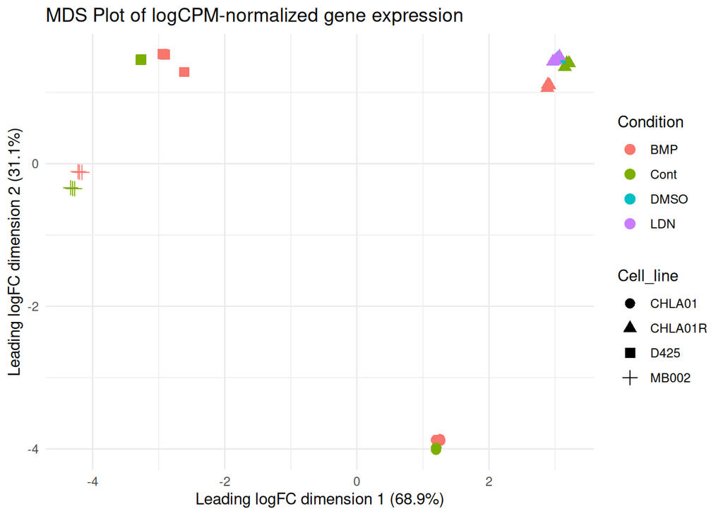

```r
# Calculate MDS
mds_result <- plotMDS(dge, plot = FALSE)

# Extract MDS coordinates
mds_df <- data.frame(
  MDS1 = mds_result$x,
  MDS2 = mds_result$y
)

# Add sample names as rownames
rownames(mds_df) <- colnames(dge$counts)

# Add metadata
mds_df$Condition <- metadata$condition
mds_df$Cell_line <- metadata$cell_line
mds_df$sample_id <- rownames(mds_df)

# As edgeR’s plotMDS function does not give variance percentages, I will estimate them using the distances between samples

# Leading logFC dimensions are proportional to the root mean square distances
var1 <- (sd(mds_df$MDS1)^2) / sum(sd(mds_df$MDS1)^2 + sd(mds_df$MDS2)^2) * 100
var2 <- (sd(mds_df$MDS2)^2) / sum(sd(mds_df$MDS1)^2 + sd(mds_df$MDS2)^2) * 100

# Plot MDS

ggplot(mds_df, aes(MDS1, MDS2, color = Condition, shape = Cell_line)) +
  geom_point(size = 3) +
  labs(title = "MDS Plot of logCPM-normalized gene expression",
        x = paste0("Leading logFC dimension 1 (", round(var1,1), "%)"),
        y = paste0("Leading logFC dimension 2 (", round(var2,1), "%)")
  )  + theme_minimal()
```

**Figure 2. MDS plot of TMM-normalized log-CPM gene expression across 30 samples. Samples are colored by condition (BMP, Control, DMSO, LDN) and shaped by cell line (CHLA01R, D425, CHLA01, MB002). This plot allows visualization of sample clustering and identification of potential outliers.**

*This code was inspired by BCB420: Computational Systems Biology Lectures (Isserlin 2025a) and BCB420: Differential Expression Analysis (Isserlin 2025b).*

**INFERENCE**:

In the MDS plot we observe the same results as the PCA plot:

1. There are no clear outliers.
2. Clustering is mainly due to cell line, and within a cell line, samples tend to cluster by condition.
3. **This hierarchical clustering pattern is important for our further differential expression analysis, particularly for our model design.**

# 5 Normalization

## 5.1 Investigating pre-normalization plots

Technical variation caused during sequencing like different sequencing depths, batch effects, gene length and GC content biases can affect our read counts. Hence, performing normalization is neccessary for reducing technical variation while leaving biological variation intact (Isserlin 2025b).

Let us first start, by looking at the distribution of our data.

### 5.1.1 Box Plots

Let us first plot our data as a box plot.

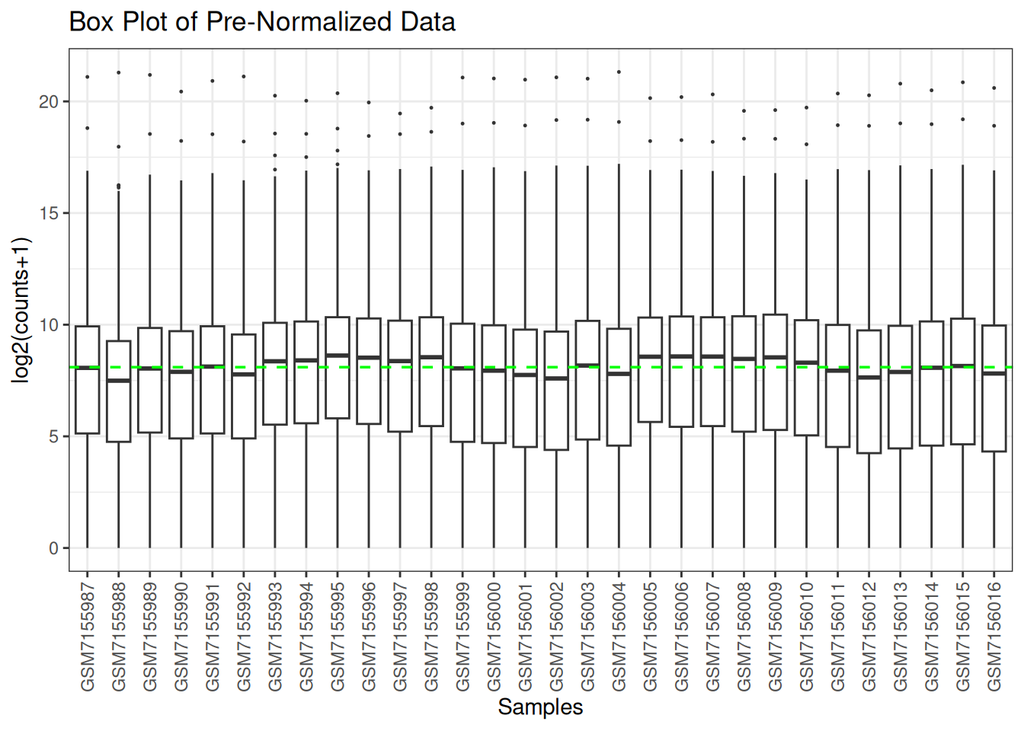

```r
# Create plot_box function
plot_box <- function(mat, main = "", ylab = "log2(counts+1)") {
  df <- as.data.frame(mat)
  df_long <- df |>
    mutate(gene = rownames(df)) |>
    pivot_longer(-gene, names_to = "sample", values_to = "value") |>
    mutate(value = log2(value + 1))

  # Calculate median of per-sample medians
  sample_medians <- df_long |>
    group_by(sample) |>
    summarize(med = median(value, na.rm = TRUE))
  overall_median <- median(sample_medians$med)

  # Plot the data
  ggplot(df_long, aes(x = sample, y = value)) +
    geom_boxplot(outlier.size = 0.2) +
    geom_hline(yintercept = overall_median,
               linetype = "dashed",
               color = "green",
               linewidth = 0.6) +
    theme_bw() +
    theme(
      axis.text.x = element_text(angle = 90, vjust = 0.5, hjust = 1),
      plot.caption = element_text(hjust = 0.5)  # Center the caption
    ) +
    labs(
      title = main,
      x = "Samples",
      y = ylab)
}



# Call the function with our dataset.
plot_box(final_mapped_counts,
         main = "Box Plot of Pre-Normalized Data")
```

**Figure 3. Boxplot of raw (pre-normalized) gene expression counts for all samples. The y-axis shows log2(counts + 1) values for each sample. The dashed green line represents the median of per-sample medians, providing a reference for overall expression levels.**

*This code was inspired by BCB420: Computational Systems Biology Lectures (Isserlin 2025a) and BCB420: Normalization rendered notebook (Isserlin 2025b).*

**INFERENCE**

From our pre-normalized box plot we can infer:

1. The range of log-normalized counts is fairly consistent across samples with some differences.
2. There are some genes with high expression (as indicated by the black dots).
3. If we observe the median values per sample (thick black line in each box), it is close to the median value across all samples (green line).

### 5.1.2 Density Plots

Let us plot our data as a density plot.

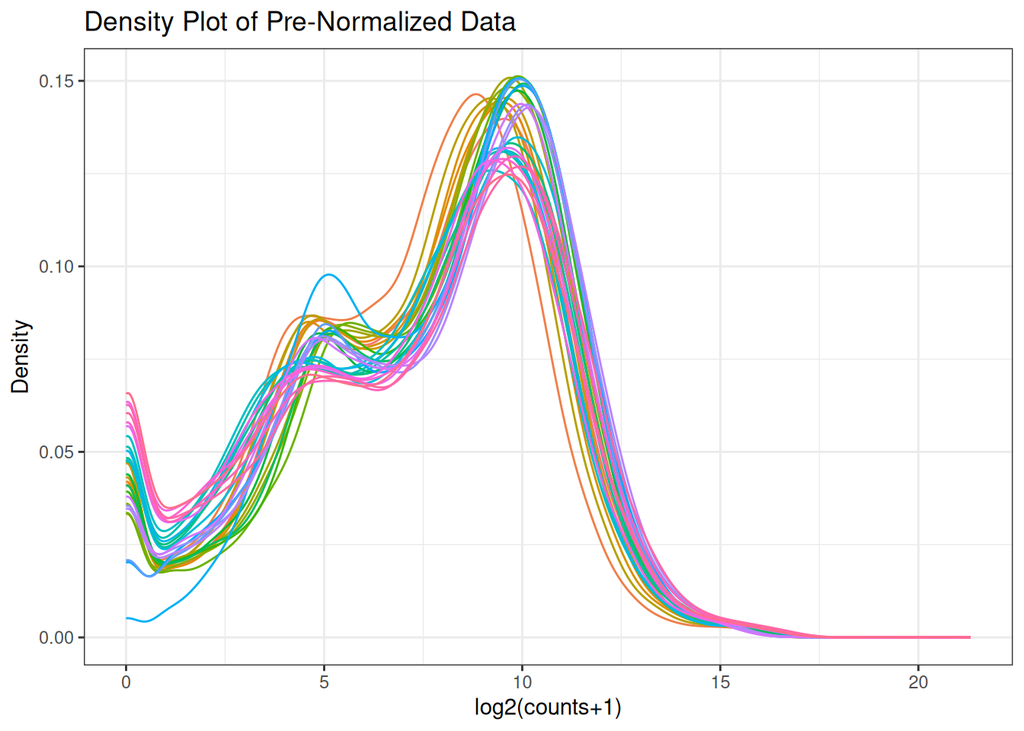

```r
# Create plot_density function
plot_density <- function(mat, main = "") {
  df <- as.data.frame(mat)
  df_long <- df |>
    mutate(gene = rownames(df)) |>
    pivot_longer(-gene, names_to = "sample", values_to = "value") |>
    mutate(value = log2(value + 1))

  # Plot the data
  ggplot(df_long, aes(x = value, colour = sample)) +
    geom_density() +
    theme_bw() +
    labs(title = main, x = "log2(counts+1)", y = "Density") +
    guides(colour = "none")
}

# Call the function with our dataset.
plot_density(final_mapped_counts,
             main = "Density Plot of Pre-Normalized Data")
```

**Figure 4. Density plot of raw (pre-normalized) gene expression counts across all samples. The x-axis represents values transformed as log2(counts + 1) for each sample. The y-axis represents the probability density of the counts for each sample. Each colour represents a different sample**

*This code was inspired by BCB420: Computational Systems Biology Lectures (Isserlin 2025a) and BCB420: Normalization rendered notebook (Isserlin 2025b).*

**INFERENCE**

From our pre-normalized density plots we can infer:

1. The peak from ~7 to ~13 indicates that most genes tend to lie in this range.
2. However, we notice that this data does not seem to be normally distributed, as it seems to be biased towards the left side, instead of a bell shape curve. The distribution does not seem centered.

## 5.2 Peforming Normalization

**Normalization method used:** Trimmed Mean of M-values (TMM) implemented in the edgeR (Chen et al. 2025) package

**Reasons to use TMM normalization method:**

1. This method is based on the hypothesis that most genes are not differentially expressed, which aligns with the expectations of our dataset.
2. TMM accounts for library size differences and corrects for composition bias, ensuring that expression comparisons across samples are accurate and not skewed by technical variation (Isserlin 2025a).

Using edgeR (Chen et al. 2025) we apply normalization to our counts.

```r
# Create a DGEList object from the counts matrix
dge_obj <- edgeR::DGEList(counts = final_mapped_counts)
# Calculate normalization factors using the TMM method
dge_obj <- edgeR::calcNormFactors(dge_obj, method = "TMM")

# Calculate CPM) values from the DGEList
normalized_counts <- edgeR::cpm(dge_obj)
```

## 5.3 Investigating post-normalization plots

Now that we have performed normalization, let us revisit our plots.

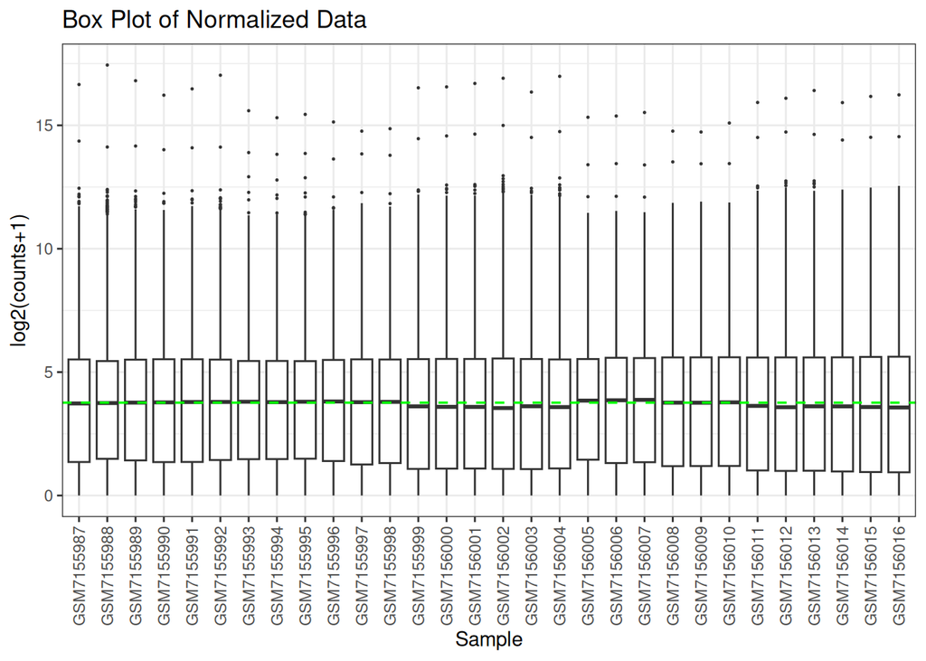

```r
# Create plot_box function
plot_box <- function(mat, main = "", ylab = "log2(counts+1)") {
  df <- as.data.frame(mat)
  df_long <- df |>
    mutate(gene = rownames(df)) |>
    pivot_longer(-gene, names_to = "sample", values_to = "value") |>
    mutate(value = log2(value + 1))

  # Calculate median of per-sample medians
  sample_medians <- df_long |>
    group_by(sample) |>
    summarize(med = median(value, na.rm = TRUE))
  overall_median <- median(sample_medians$med)

  # Plot the data
  ggplot(df_long, aes(x = sample, y = value)) +
    geom_boxplot(outlier.size = 0.2) +
    geom_hline(yintercept = overall_median,
               linetype = "dashed",
               color = "green",
               linewidth = 0.6) +
    theme_bw() +
    theme(axis.text.x = element_text(angle = 90, vjust = 0.5, hjust = 1)) +
    labs(title = main, x = "Sample", y = ylab)
}

# Call the function with our dataset.
plot_box(normalized_counts,
         main = "Box Plot of Normalized Data")
```

**Figure 5. Boxplot of normalized gene expression counts for all samples. The y-axis shows log2(counts + 1) values for each sample. The dashed green line represents the median of per-sample medians, providing a reference for overall expression levels.**

**INFERENCE**

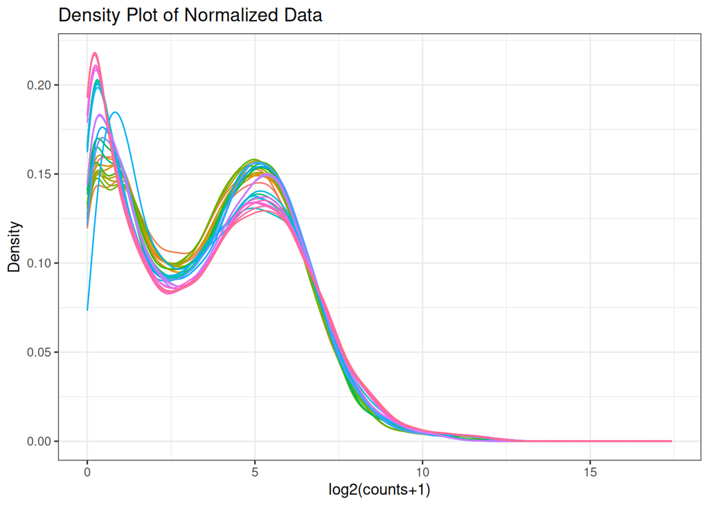

```r
# Create plot_density function
plot_density <- function(mat, main = "") {
  df <- as.data.frame(mat)
  df_long <- df |>
    mutate(gene = rownames(df)) |>
    pivot_longer(-gene, names_to = "sample", values_to = "value") |>
    mutate(value = log2(value + 1))

  # Plot the data
  ggplot(df_long, aes(x = value, colour = sample)) +
    geom_density() +
    theme_bw() +
    labs(title = main, x = "log2(counts+1)", y = "Density") +
    guides(colour = "none")
}

# Call it with your data
plot_density(normalized_counts,
             main = "Density Plot of Normalized Data")
```

**Figure 6. Density plot of normalized gene expression counts across all samples. The x-axis represents values transformed as log2(counts + 1) for each sample. The y-axis represents the probability density of the counts for each sample. Each colour represents a different sample**

**INFERENCE**

By our comparing our post-normalized density plots to our pre-normalized density plots we can infer:

1. There are a large number of low read counts particularly highlighted by the peak around 0 to 3, which was not as prominent in the pre-normalization data.
2. This can be possibly due to our **normalization** followed by log2(counts + 1) transformation in our density plot code, amplifying the noise in the lowly expressed genes. Small changes in these low counts, can become huge changes on this log scale.
3. Although the MDS plot did not have any outliers, this suggests that maybe having stricter thresholds than the standard workflow of low-level filtering is needed.

# 6 Differential Gene Expression

## 6.1 Biological Replicates

The dataset comprises of 30 samples spanning four medulloblastoma cell lines (CHLA01, CHLA01R, MB002, and D425) across two primary treatment comparisons. For each treatment condition within a given cell line, three biological replicates were generated, as outlined below.

**BMP7 vs Control**

*3 CHLA01-BMP

*3 CHLA01-Control

*3 CHLA01R-BMP

*3 CHLA01R-Control

*3 MB002-BMP

*3 MB002-Control

*3 D425-BMP

*3 D425-Control

**LDN (BMP signaling inhibitor) treatment vs DMSO**

*3 CHLA01R-LDN

*3 CHLA01R-DMSO

To understand how to handle biological replicates in downstream analyses, let us revisit the **MDS plot**.

**INFERENCE**

As observed previously, sample clustering is driven primarily by cell line, with samples further segregating by treatment condition within each cell line. Additionally, BMP-treated and control samples form distinct clusters, indicating a clear treatment-associated signal. Because cell line identity is a strong source of variation, pooling samples across different cell lines (i.e. analyzing all BMP-treated samples versus all controls without accounting for cell line) would risk identifying genes that reflect intrinsic cell line differences rather than treatment effects. For this reason, I decided not to combine biological replicates across cell lines.

Instead, I focused on the CHLA01 cell line, which exhibits tight clustering of BMP samples and control samples in the MDS plot. Hence, differential expression analysis was restricted to BMP vs control comparisons within the CHLA01 cell line to understand treatment-specific transcriptional changes.

## 6.2 Biological Coefficient of Variation

Let us set up our model design based on our choice of factors in the model:

```r
# Focusing on CHLA01 cell line for BMP treated and control groups

# Extract associated metadata
metadata_for_de <- metadata[metadata$cell_line == "CHLA01" &
                             metadata$condition %in% c("BMP","Cont"), c("cell_line", "condition", "GEO_ID")]

# Convert condition to factor with reference as Control
metadata_for_de$condition <- factor(metadata_for_de$condition, levels = c("Cont", "BMP"))


# 0 is Control, 1 is BMP
model_design <- model.matrix(~ metadata_for_de$condition)

head(model_design)
```

```
##   (Intercept) metadata_for_de$conditionBMP
## 1           1                            1
## 2           1                            1
## 3           1                            1
## 4           1                            0
## 5           1                            0
## 6           1                            0
```

**Table 10. Design matrix for differential expression analysis in the CHLA01 cell line, coding the treatment condition (Control vs. BMP) for use in linear modeling.**

Next, let us estimate dispersion and plot a Biological Coefficient of Variation (BCV) plot.

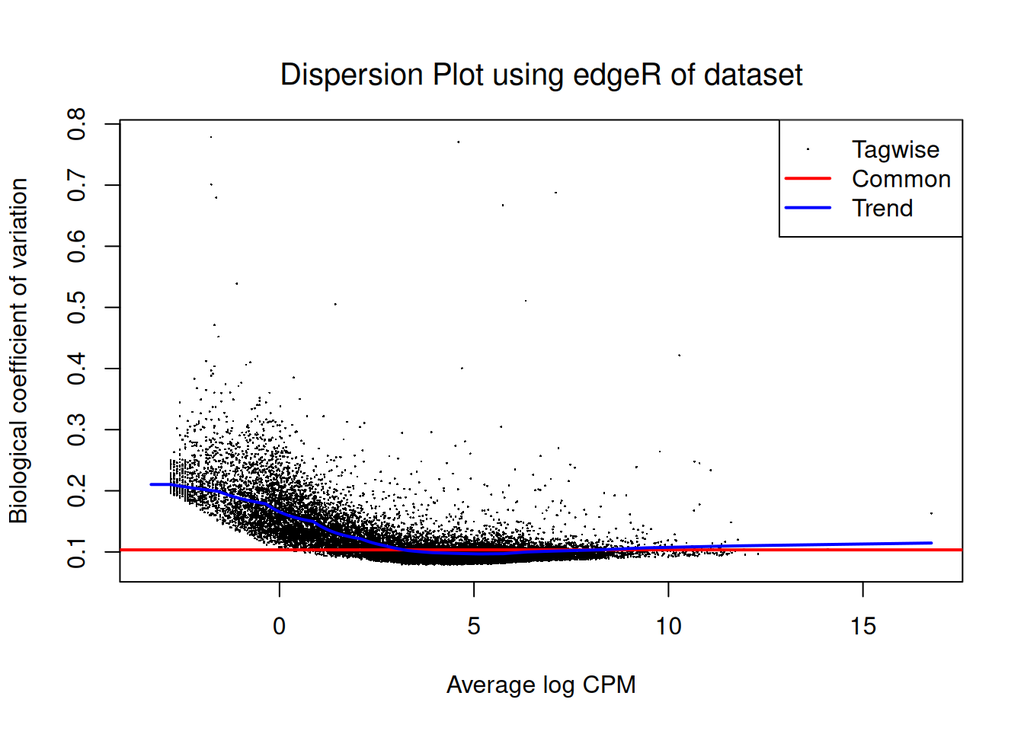

```r
# Create DGEList object
de_samples_expression <-  final_mapped_counts[, colnames(final_mapped_counts) %in% metadata_for_de$GEO_ID]

dge_obj_for_de <-  DGEList(counts=de_samples_expression,
            group=metadata_for_de$condition)

# Estimate dispersion with edgeR
dispersion_estimate <- estimateDisp(dge_obj_for_de, model_design)

# Plot Biological coefficient of variation
edgeR::plotBCV(dispersion_estimate)

# Adding Title to Plot
mtext("Dispersion Plot using edgeR of dataset", side = 3, line = 1, cex = 1.25)
```

**Figure 5. Biological coefficient of variation (BCV) plot using edgR. The x-axis represents the gene expression abundance (average log CPM), while the y-axis represents biological variability. Each black point represents a gene, with the common dispersion (red line) indicating overall variability and the trended dispersion (blue line) showing abundance-dependent variation.**

## 6.3 Differential Analysis

Using edgeR (Chen et al. 2025) we perform differential analysis, to identify genes whose expression differs in BMP vs Control samples. Let us look at the tagwise differential expression results table generated by the quasi-likelihood (QL) test.

```r
# Fit the model (Quasi-likelihood)
fitted_model <- glmQLFit(dispersion_estimate, model_design)

# Calculate DE
qlf_bmp_vs_control <- glmQLFTest(fitted_model)

qlf_output <- topTags(qlf_bmp_vs_control,
                           sort.by = "PValue",
                           n = nrow(de_samples_expression))

de_output <- qlf_output$table

# View results
head(de_output)
```

|  | logFC | logCPM | F | PValue | FDR |
| --- | --- | --- | --- | --- | --- |
| SMAD6 | 8.014673 | 2.948043 | 674.5713 | 1.175364e-15 | 7.018727e-12 |
| KCNJ5 | 6.493063 | 3.948327 | 1073.0182 | 1.216712e-15 | 7.018727e-12 |
| SAMD11 | 6.049852 | 4.797136 | 1046.2752 | 1.340392e-15 | 7.018727e-12 |
| ID3 | 4.374305 | 5.499262 | 1020.1900 | 1.607772e-15 | 7.018727e-12 |
| ID1 | 4.236215 | 5.470221 | 835.4873 | 7.332022e-15 | 2.560636e-11 |
| ID2 | 3.330014 | 5.271338 | 758.6143 | 1.523542e-14 | 4.434015e-11 |

**Table 11. Top differentially expressed genes from the quasi-likelihood (QL) test comparing BMP-treated versus Control samples, showing log-fold changes, average expression, and associated p-values.**

Next, we will filter for differentially expressed genes. The standard workflow uses a p-value threshold of 0.05 to identify statistically significant changes (Spang 2024).

```r
# Number of DE genes
length(which(de_output$PValue < 0.05))
```

```
## [1] 4931
```

Using the p-value threshold, we identify 4931 significantly differentially expressed genes in our dataset.

## 6.4 Multiple Hypothesis Testing

As we are performing many statistical tests simultaneously (one for each gene), this increases the likelihood that some genes will appear statistically significant purely by chance. Without correction, our list of “significant” genes would be dominated by false positives. To address this, let us apply the Benjamini-Hochberg (BH) method to adjust p-values, which controls the false discovery rate (FDR).

This correction accounts for the number of tests being performed and helps us distinguish true biological signals from random statistical noise. We then assess how many genes meet commonly used significance thresholds of FDR < 0.05 (Chen et al. 2017)

```r
## Adjusted p-values for multiple hypothesis testing
de_output$p_adj <- p.adjust(de_output$PValue, method = "BH")

# Genes passing threshold
length(which(de_output$p_adj < 0.05))
```

```
## [1] 2538
```

After applying both the p-value and FDR thresholds, 2538 genes remain significantly differentially expressed.

## 6.5 Volcano plot

To visualize the results of differential expression analysis, let us generate a volcano plot and highlight specific genes of biological interest.

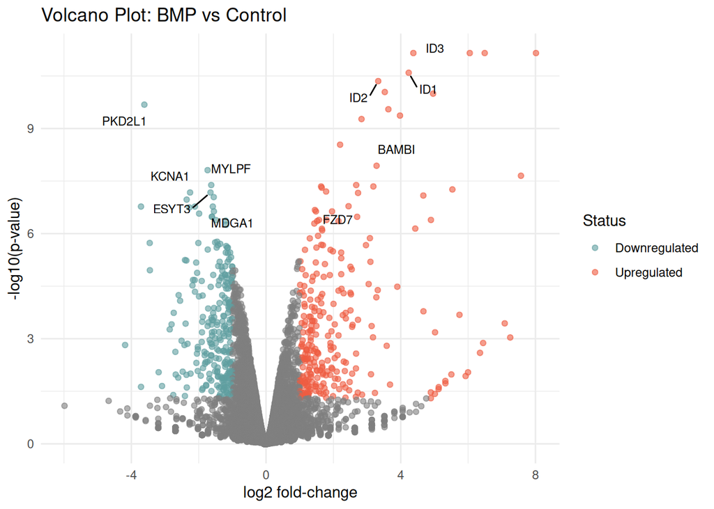

```r
# Plot differentially expressed genes in a volcano plot

genes_to_plot <- c("ESYT3", "BAMBI", "FZD7", "ID2", "MDGA1","MYLPF", "ID3", "KCNA1", "PKD2L1", "ID1")

# Plot a volcano plot with annotations
volcano_df <- de_output %>%  mutate(Status = case_when(
  logFC > 1 & FDR < 0.05 ~ "Upregulated",
  logFC < -1 & FDR < 0.05 ~ "Downregulated",
  TRUE ~ "Non-significant"
)) %>% mutate(gene_name = rownames(.))

ggplot(volcano_df, aes(x = logFC, y = -log10(FDR), color = Status)) +
  geom_point(alpha = 0.6) +
  scale_color_manual(values = c("Upregulated" = "tomato2",
                                "Downregulated" = "cadetblue",
                                "Non-signficant" = "grey")) +
  geom_text_repel(
  data = volcano_df %>% filter(gene_name %in% genes_to_plot),
  aes(label = gene_name),
  size = 3,
  max.overlaps = 20,
  box.padding = 0.5,
  point.padding = 0.3,
  color = "black")  +
  theme_minimal() +
  labs(
    title = "Volcano Plot: BMP vs Control",
    x = "log2 fold-change",
    y = "-log10(p-value)"
  )
```

**INFERENCE**

There appears to be more upregulated genes than downregulated genes, and the upregulated genes show higher fold-changes, while downregulated genes are more modest. Genes ID1, ID2 and ID3 are highly up-regulated, and are a well-established target of BMP signaling (Korchynskyi and Dijke 2002).

## 6.6 Heatmap

To visualize the expression patterns of the most significantly differentially expressed genes, let us generate a heatmap using the top 25 genes with the strongest signal (absolute log2 fold change > 1 and FDR < 0.05).

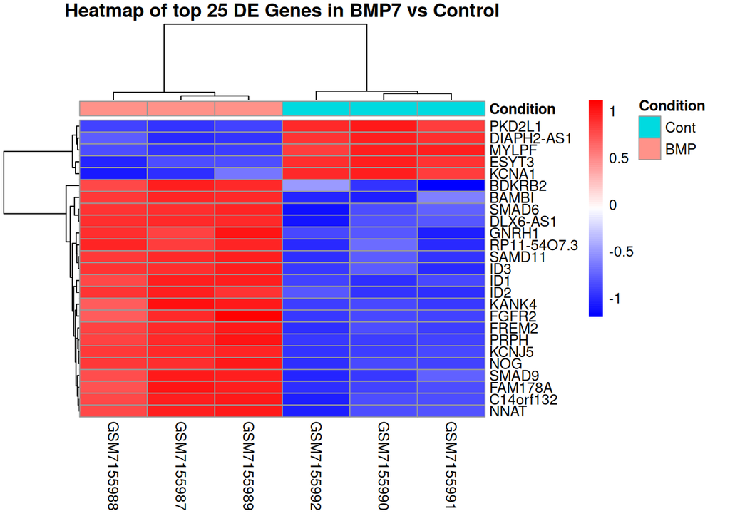

```r
# logCPM from counts for visualization
# logCPM for visualization
logcpm <- edgeR::cpm(de_samples_expression, log = TRUE, prior.count = 1)

# Keep only genes present in the expression matrix
top_hits <- volcano_df[volcano_df$p_adj < 0.05 & abs(volcano_df$logFC) > 1,] %>% slice_head(n = 25)
top_hits <- rownames(top_hits)

heatmap_matrix <- logcpm[top_hits, ]

# If duplicated HGNC symbols, make rownames unique
if (any(duplicated(rownames(heatmap_matrix)))) {
  rownames(heatmap_matrix) <- make.unique(hm_labels)
}

# Z-score per gene across samples for pattern visibility
heatmap_matrix_z <- t(scale(t(heatmap_matrix)))


annotation_cols <- data.frame(Condition = metadata_for_de$condition,
                              row.names = colnames(heatmap_matrix_z))

pheatmap(
  heatmap_matrix_z,  scale = "none",
  color = colorRampPalette(c("blue", "white", "red"))(100),
  cluster_rows = TRUE,
  cluster_cols = TRUE,
  annotation_col = annotation_cols,
  show_rownames = TRUE,
  main = "Heatmap of top 25 DE Genes in BMP7 vs Control"
)
```

**Figure 8. Heatmap of the top 25 differentially expressed genes with the strongest signal (absolute log2 fold change > 1 and FDR < 0.05) in BMP7-treated versus control medulloblastoma cells. Expression values are shown as scaled Z-scores (red = high expression, blue = low expression).**

**INFERENCE**

1. **Strong clustering by condition:** We observe strong clustering by condition by the clear separation between BMP7-treated (BMP, pink annotation) and control (Cont, cyan annotation) samples.
2. **Clear separation of gene expression patterns:** The top 25 DE genes show a clean distinction. Genes are either strongly upregulated in BMP-treated samples (red clusters) or strongly downregulated (blueclusters). There’s minimal intermediate expression, suggesting these are strongly regulated genes.
3. **Reproducibility:** Within each condition, the three replicates show very similar expression patterns as seen by the vertical consistency within BMP and Control groups, highlighting good experimental reproducibility.

*This code was inspired by BCB420: “Differential Expression” rendered notebook (Isserlin 2025b).*

Hence our conditions cluster together, as the top 25 differentially expressed genes show consistent and opposing expression patterns between BMP-treated and control samples. By selecting genes with the largest expression differences between conditions, we have chosen features that maximize separation between groups. BMP samples uniformly upregulate one set of genes while downregulating another, and control samples show the opposite pattern.

# 7 Final Coverage

Let us analyze the final coverage of our dataset.

```r
nrow(normalized_counts)
```

```
## [1] 17462
```

The final coverage of the dataset is `17462` genes across 30 samples.

# 8 Conclusion

Our report successfully analyzed bulk RNA-sequencing data from BMP7-treated medulloblastoma cells, reducing the initial dataset from 66,023 genes to a final coverage of 17,462 well-expressed, uniquely mapped genes across 30 samples.

Following TMM normalization and quality control, differential expression analysis between BMP7-treated and control CHLA01 cells identified 2,538 significantly differentially expressed genes (FDR < 0.05). Canonical BMP signaling targets ID1, ID2, and ID3 showed strong upregulation, validating pathway activation. The perfect clustering of biological replicates by treatment condition in both PCA/MDS plots and the heatmap of top 25 differentially expressed genes demonstrates robust and reproducible transcriptional responses to BMP7 signaling.

# 9 Interpret, and Document

The following questions are related to the Content rubric of Assignment 1. These questions are linked to relevant sections from the assignment.

**Why is the dataset of interest to you?**

**What are the control and test conditions of the dataset?**

**How many samples in each of the conditions of your dataset?**

**Were there expression values that were not unique for specific genes? How did you handle these?**

**Were there expression values that could not be mapped to current HUGO symbols?**

**Were there any outliers in your dataset? How were they handled in the originating paper? How many outliers were removed?**

**How did you handle replicates?**

**What is the final coverage of your dataset?**

# 10 Journal Documentation

Link to my [Wiki](https://github.com/bcb420-2026/Tanaya_Datar/wiki) with four Assignment-1 related documentation pages.

# References

Bioconductor Support Forum. 2023. “Filtering Step for Differential Analysis in edgeR.” https://support.bioconductor.org/p/108798/.

Chen, Shi-Yi, Zhe Feng, and Xiaolian Yi. 2017. “A General Introduction to Adjustment for Multiple Comparisons.” *Journal of Thoracic Disease* 9 (6): 1725–29. https://doi.org/10.21037/jtd.2017.05.34.

Chen, Yunshun, Luyi Chen, Aaron T L Lun, Paolo Baldoni, and Gordon K Smyth. 2025. “edgeR V4: Powerful Differential Analysis of Sequencing Data with Expanded Functionality and Improved Support for Small Counts and Larger Datasets.” *Nucleic Acids Research* 53 (2): gkaf018. https://doi.org/10.1093/nar/gkaf018.

Chen, Yunshun, Aaron T. L. Lun, and Gordon K. Smyth. 2016. “From Reads to Genes to Pathways: Differential Expression Analysis of RNA-Seq Experiments Using Rsubread and the edgeR Quasi-Likelihood Pipeline.” *F1000Research* 5: 1438. https://doi.org/10.12688/f1000research.8987.2.

Cooney, Tyler, Hannah Lindsay, Sara Leary, and Robert Wechsler-Reya. 2023. “Current Studies and Future Directions for Medulloblastoma: A Review from the Pacific Pediatric Neuro-Oncology Consortium (PNOC) Disease Working Group.” *Neoplasia* 35: 100861. https://doi.org/10.1016/j.neo.2022.100861.

Davis, Shawn, and Paul S Meltzer. 2007. “GEOquery: A Bridge Between the Gene Expression Omnibus (GEO) and BioConductor.” *Bioinformatics* 23 (14): 1846–47. https://doi.org/10.1093/bioinformatics/btm254.

Durinck, Sandrine, Paul T Spellman, Ewan Birney, and Wolfgang Huber. 2009. “Mapping Identifiers for the Integration of Genomic Datasets with the r/Bioconductor Package biomaRt.” *Nature Protocols* 4: 1184–91. https://doi.org/10.1038/nprot.2009.97.

Harvey, David T., and Bryan A. Hanson. 2024. *Step-by-Step PCA*. LearnPCA R package. https://cran.r-project.org/web/packages/LearnPCA/vignettes/Vig\_03\_Step\_By\_Step\_PCA.pdf.

Isserlin, Ruth. 2025a. *BCB420: Computational Systems Biology Lectures*.

Isserlin, Ruth. 2025b. *BCB420: Computational Systems Biology Notebooks*.

Kolde, Raivo. 2025. *Pheatmap: Pretty Heatmaps*. https://github.com/raivokolde/pheatmap.

Korchynskyi, Olexander, and Peter ten Dijke. 2002. “Identification and Functional Characterization of Distinct Critically Important Bone Morphogenetic Protein-Specific Response Elements in the Id1 Promoter.” *Journal of Biological Chemistry* 277 (7): 4883–91. https://doi.org/10.1074/jbc.M111023200.

Love, Michael I, Simon Anders, and Wolfgang Huber. 2025. *Analyzing RNA‑seq Data with DESeq2*. Bioconductor Project. https://www.bioconductor.org/packages/release/bioc/vignettes/DESeq2/inst/doc/DESeq2.html.

Ohata, Yae, Mohamad M Ali, Yutaro Tsubakihara, et al. 2025. “The Transcription Factor LHX2 Mediates and Enhances Oncogenic BMP Signaling in Medulloblastoma.” *Cell Death & Differentiation* 32: 1915–29. https://doi.org/10.1038/s41418-025-01488-6.

Slowikowski, Kamil. 2024. *Ggrepel: Automatically Position Non-Overlapping Text Labels with ’Ggplot2’*.

Spang, Rainer. 2024. *Screening*. University of Regensburg; Lecture notes in the course Statistical Bioinformatics: Gene Expression Data Analysis. https://www.uni-regensburg.de/assets/medicine/statistical-bioinformatics/03_screening.pdf.

Wickham, Hadley. 2016. *Ggplot2: Elegant Graphics for Data Analysis*. Springer-Verlag New York. https://ggplot2.tidyverse.org.

Wickham, Hadley, Mara Averick, Jennifer Bryan, et al. 2019. “Welcome to the tidyverse.” *Journal of Open Source Software* 4 (43): 1686. https://doi.org/10.21105/joss.01686.

Wickham, Hadley, Romain François, Lionel Henry, Kirill Müller, and Davis Vaughan. 2026. *Dplyr: A Grammar of Data Manipulation*. https://dplyr.tidyverse.org.